# GA

Andy Quintero

#### The sample dataset contains obfuscated Google Analytics 360 data from the Google Merchandise Store, a real ecommerce store that sells Google branded merchandise. The dataset was pulled using Google’s BigQuery.

## Load libraries

```r
library(dplyr, warn.conflicts = FALSE) # suppress conflicts warning
options(dplyr.summarise.inform = FALSE) # Suppress summarise info

library(tidyr)
library(ggplot2)

# date/time libaray
library(lubridate, warn.conflicts = FALSE)
```

## Read dataset and show its structure

```r
df<- read.csv(file = "bq-results.csv")
names(df)
```

```
 [1] "date"                    "userID"                  "sessionID"               "session"                 "pageviews"               "newVisits"               "transactions"
 [8] "visits"                  "totalTransactionRevenue" "browser"                 "deviceCategory"          "country"                 "region"                  "hitNumber"
[15] "pagePath"
```

## Transformations

```r
df$userID =  as.character(df$userID)
df$sessionID =  as.character(df$sessionID)

df$date = as.Date(as.character(df$date), "%Y%m%d")
df$dow =  wday(df$date) # new column

# replace NA with 0
df$transactions[is.na(df$transactions)] <- 0
df$totalTransactionRevenue[is.na(df$totalTransactionRevenue)] <- 0
df$newVisits[is.na(df$newVisits)] <- 0

# scale
df$totalTransactionRevenue =df$totalTransactionRevenue/1000000 # scale

# new columns
df$newVisits =  factor(ifelse(df$newVisits  == 1, 'yes', 'no'))
df$hasTransaction =  factor(ifelse(df$transactions >= 1, 'yes', 'no'))

df$hitNumber = NULL;  # not useful

str(df)
```

```
'data.frame':   281493 obs. of  16 variables:
 $ date                   : Date, format: "2017-07-09" "2017-07-19" "2017-07-19" "2017-07-19" ...
 $ userID                 : chr  "62267706107999" "85059828173212" "436683523507380" "436683523507380" ...
 $ sessionID              : chr  "1499645960" "1500505105" "1500504900" "1500504900" ...
 $ session                : int  1 1 1 1 2 2 2 2 2 2 ...
 $ pageviews              : int  1 1 2 2 8 8 8 8 8 8 ...
 $ newVisits              : Factor w/ 2 levels "no","yes": 2 2 2 2 1 1 1 1 1 1 ...
 $ transactions           : num  0 0 0 0 0 0 0 0 0 0 ...
 $ visits                 : int  1 1 1 1 1 1 1 1 1 1 ...
 $ totalTransactionRevenue: num  0 0 0 0 0 0 0 0 0 0 ...
 $ browser                : chr  "Chrome" "Safari" "Chrome" "Chrome" ...
 $ deviceCategory         : chr  "desktop" "mobile" "desktop" "desktop" ...
 $ country                : chr  "Brazil" "United States" "United States" "United States" ...
 $ region                 : chr  "not available in demo dataset" "Illinois" "New York" "New York" ...
 $ pagePath               : chr  "/home" "/asearch.html" "/home" "/google+redesign/electronics/power/clip+compact+charger.axd" ...
 $ dow                    : num  1 4 4 4 3 3 3 3 3 3 ...
 $ hasTransaction         : Factor w/ 2 levels "no","yes": 1 1 1 1 1 1 1 1 1 1 ...
```

#### 281493 observations and 16 variables including new columns

## Top and Bottom

```r
head(df, 10)
```

|  | date | userID | sessionID | session | pageviews | newVisits | transactions | visits | totalTransactionRevenue | browser | deviceCategory | country | region | pagePath | dow | hasTransaction |
| --- | --- | --- | --- | --- | --- | --- | --- | --- | --- | --- | --- | --- | --- | --- | --- | --- |
| 1 | 2017-07-09 | 62267706107999 | 1499645960 | 1 | 1 | yes | 0 | 1 | 0 | Chrome | desktop | Brazil | not available in demo dataset | /home | 1 | no |
| 2 | 2017-07-19 | 85059828173212 | 1500505105 | 1 | 1 | yes | 0 | 1 | 0 | Safari | mobile | United States | Illinois | /asearch.html | 4 | no |
| 3 | 2017-07-19 | 436683523507380 | 1500504900 | 1 | 2 | yes | 0 | 1 | 0 | Chrome | desktop | United States | New York | /home | 4 | no |
| 4 | 2017-07-19 | 436683523507380 | 1500504900 | 1 | 2 | yes | 0 | 1 | 0 | Chrome | desktop | United States | New York | /google+redesign/electronics/power/clip+compact+charger.axd | 4 | no |
| 5 | 2017-07-25 | 436683523507380 | 1500989127 | 2 | 8 | no | 0 | 1 | 0 | Chrome | desktop | United States | New York | /home | 3 | no |
| 6 | 2017-07-25 | 436683523507380 | 1500989127 | 2 | 8 | no | 0 | 1 | 0 | Chrome | desktop | United States | New York | /google+redesign/bags/backpacks/waterproof+backpack.axd | 3 | no |
| 7 | 2017-07-25 | 436683523507380 | 1500989127 | 2 | 8 | no | 0 | 1 | 0 | Chrome | desktop | United States | New York | /home | 3 | no |
| 8 | 2017-07-25 | 436683523507380 | 1500989127 | 2 | 8 | no | 0 | 1 | 0 | Chrome | desktop | United States | New York | /home | 3 | no |
| 9 | 2017-07-25 | 436683523507380 | 1500989127 | 2 | 8 | no | 0 | 1 | 0 | Chrome | desktop | United States | New York | /google+redesign/electronics | 3 | no |
| 10 | 2017-07-25 | 436683523507380 | 1500989127 | 2 | 8 | no | 0 | 1 | 0 | Chrome | desktop | United States | New York | /google+redesign/office/notebooks+journals/google+spiral+journal+with+pen.axd | 3 | no |

```r
tail(df)
```

|  | date | userID | sessionID | session | pageviews | newVisits | transactions | visits | totalTransactionRevenue | browser | deviceCategory | country | region | pagePath | dow | hasTransaction |
| --- | --- | --- | --- | --- | --- | --- | --- | --- | --- | --- | --- | --- | --- | --- | --- | --- |
| 281488 | 2017-07-25 | 9999430912254902272 | 1500972450 | 1 | 24 | yes | 0 | 1 | 0 | Chrome | desktop | Singapore | (not set) | /google+redesign/apparel/mens/mens+t+shirts | 3 | no |
| 281489 | 2017-07-25 | 9999430912254902272 | 1500972450 | 1 | 24 | yes | 0 | 1 | 0 | Chrome | desktop | Singapore | (not set) | /google+redesign/apparel/mens/mens+outerwear | 3 | no |
| 281490 | 2017-07-25 | 9999430912254902272 | 1500972450 | 1 | 24 | yes | 0 | 1 | 0 | Chrome | desktop | Singapore | (not set) | /google+redesign/apparel/men+s+t+shirts/google+mens+short+sleeve+hero+tee+white.axd | 3 | no |
| 281491 | 2017-07-25 | 9999430912254902272 | 1500972450 | 1 | 24 | yes | 0 | 1 | 0 | Chrome | desktop | Singapore | (not set) | /google+redesign/apparel/mens/mens+outerwear | 3 | no |
| 281492 | 2017-07-05 | 9999594748540438528 | 1499262993 | 2 | 1 | no | 0 | 1 | 0 | Safari | desktop | United States | New York | /home | 4 | no |
| 281493 | 2017-07-01 | 9999944980984229888 | 1498900256 | 1 | 1 | yes | 0 | 1 | 0 | Chrome | desktop | India | Telangana | /home | 7 | no |

#### - Observation 1 and 2 corresponds to 2 users who only visited a single page.

#### - Observation 3-4 pertain to the same user/session in which the user visited 2 separate pages (pageviews and pagePath) for a given visit.

#### -However that same user is associated with more than one session as observed by observation 5,6,7, etc..

## Summary

#### summarize by distinct sessionID. If we were interested in pagePath, we would need to include userID in our distinct clause.

#### userID SessionID Session PageViews pagePath

#### 436683523507380 1500504900 1 2 /home

#### 436683523507380 1500504900 1 2 /google+redesign/electronics/power/

```r
df %>%
  distinct(sessionID, .keep_all = TRUE) %>%   # don't double-count
  select( -c('userID', 'sessionID', 'dow', 'pagePath'))  %>%
  summary()
```

```
      date               session          pageviews       newVisits    transactions         visits  totalTransactionRevenue   browser          deviceCategory       country             region
 Min.   :2017-07-01   Min.   :  1.000   Min.   :  1.000   no :17473   Min.   :0.00000   Min.   :1   Min.   :    0.000       Length:72970       Length:72970       Length:72970       Length:72970
 1st Qu.:2017-07-09   1st Qu.:  1.000   1st Qu.:  1.000   yes:55497   1st Qu.:0.00000   1st Qu.:1   1st Qu.:    0.000       Class :character   Class :character   Class :character   Class :character
 Median :2017-07-17   Median :  1.000   Median :  1.000               Median :0.00000   Median :1   Median :    0.000       Mode  :character   Mode  :character   Mode  :character   Mode  :character
 Mean   :2017-07-16   Mean   :  2.203   Mean   :  3.786               Mean   :0.01498   Mean   :1   Mean   :    2.305
 3rd Qu.:2017-07-25   3rd Qu.:  1.000   3rd Qu.:  4.000               3rd Qu.:0.00000   3rd Qu.:1   3rd Qu.:    0.000
 Max.   :2017-08-01   Max.   :395.000   Max.   :186.000               Max.   :4.00000   Max.   :1   Max.   :25249.260
 hasTransaction
 no :71919
 yes: 1051
```

#### - most are new visitors (newVisits) with 0 transactions. The max number of transactions is 4.

#### - All ‘visits’ (1) resulted in interaction events (eg: downloads, mobile ad clicks, gadgets, etc).

#### - majority of users use Chrome browser followed by Safari with majority accessing the site from desktop followed by mobile.

#### - Most users access the site from the US and from CA. There are a high number of unknown country, region origin

## more cleaning

```r
df$region <- as.character(df$region)
df$region[df$region == 'not available in demo dataset'] <- 'unknown'
df$region[df$region == '(not set)'] <- 'unknown'
df$region <- as.factor(df$region)

df$country <- as.character(df$country)
df$country[df$country == '(not set)'] <- 'unknown'
df$country <- as.factor(df$country)
```

## The next table shows the top 20 pages visited

```r
df2=df %>%
  group_by(pagePath) %>%
  distinct(sessionID, .keep_all = TRUE) %>%   # don't double-count
  count(pagePath,  sort = TRUE) %>%
  head(20)

df2$pagePath <- factor(df2$pagePath,
  levels = df2$pagePath[order( df2$n, decreasing = TRUE)])

df2
```

| pagePath | n |
| --- | --- |
| /home | 40328 |
| /google+redesign/shop+by+brand/youtube | 19117 |
| /google+redesign/apparel/mens/mens+t+shirts | 6955 |
| /basket.html | 6103 |
| /signin.html | 5668 |
| /asearch.html | 4033 |
| /store.html | 3877 |
| /google+redesign/bags | 3610 |
| /google+redesign/electronics | 3592 |
| /google+redesign/apparel | 3474 |

[output cut: 10 more lines]

#### - men’s shirts appears to be a popular product

## Visualization

### Univariate plots

#### Most visited Pages

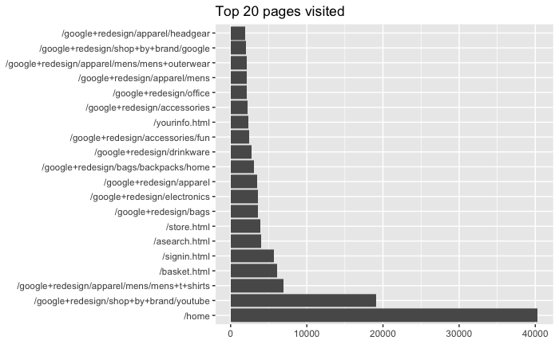

```r
ggplot(df2, aes(x = pagePath, y = n)) +
    geom_col() +
    coord_flip() +
        labs(x = NULL, y = NULL,
        title = "Top 20 pages visited")
```

#### Page Views with Transactions

```r
# unique by user ID/ sessionID
data = df %>%
  group_by(userID) %>%
  mutate(converted = ifelse(hasTransaction == 'yes', 1, 0)) %>%
  distinct(date, userID, sessionID, pageviews, transactions, converted, country,
           hasTransaction)
```

```r
 par(mfrow=c(1,2)) # 1 row, 2 columns

 group_data = filter(data, hasTransaction == 'yes' )
 group_data
```

| date | userID | sessionID | pageviews | transactions | country | hasTransaction | converted |
| --- | --- | --- | --- | --- | --- | --- | --- |
| 2017-07-18 | 6911334202687206 | 1500442011 | 19 | 1 | United States | yes | 1 |
| 2017-07-31 | 10295111715775250 | 1501549997 | 35 | 1 | United States | yes | 1 |
| 2017-07-03 | 14262055593378384 | 1499123682 | 30 | 2 | United States | yes | 1 |
| 2017-07-15 | 14262055593378384 | 1500139462 | 26 | 1 | United States | yes | 1 |
| 2017-07-22 | 24932550342595468 | 1500744389 | 26 | 2 | United States | yes | 1 |
| 2017-07-31 | 47078955120420928 | 1501541991 | 21 | 1 | United States | yes | 1 |
| 2017-07-21 | 80479763428955072 | 1500646191 | 34 | 1 | Canada | yes | 1 |
| 2017-07-25 | 82806901961150592 | 1501008172 | 51 | 1 | United States | yes | 1 |
| 2017-07-07 | 88657980877164096 | 1499463211 | 14 | 1 | United States | yes | 1 |
| 2017-07-28 | 97371986665596416 | 1501245017 | 14 | 1 | United States | yes | 1 |

[output cut: 990 more lines]

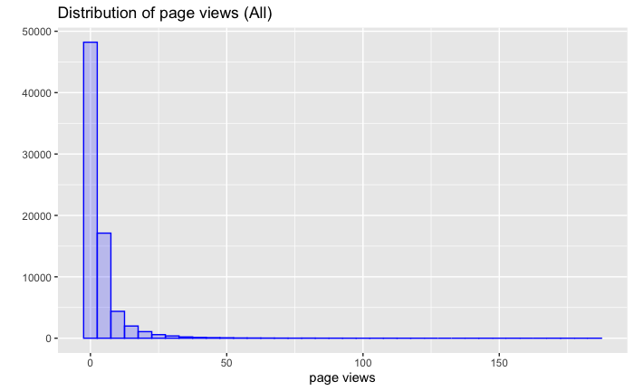

```r
 qplot(data$pageviews,
        geom="histogram",
        binwidth = 5,
        main = 'Distribution of page views (All)',
        xlab = 'page views',
        fill=I("blue"),
        col=I("blue"),
        alpha=I(.2))
```

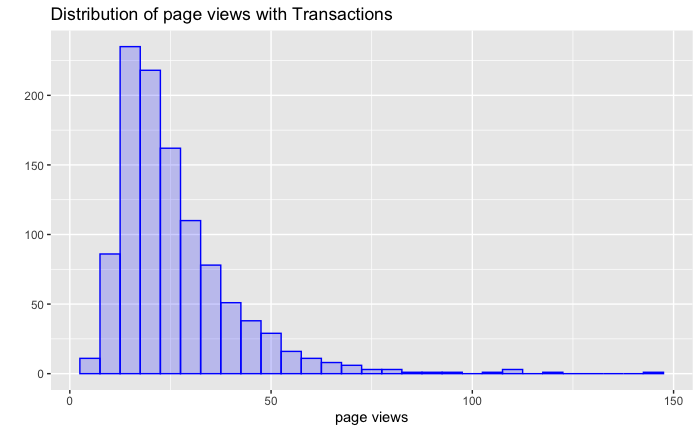

```r
  qplot(group_data$pageviews,
        geom="histogram",
        binwidth = 5,
        main = 'Distribution of page views with Transactions',
        xlab = 'page views',
        fill=I("blue"),
        col=I("blue"),
        alpha=I(.2))
```

#### Majority of users view less than 5 pages With transactions, the majority of page views is less than 25

## Density/Box plots for numeric variables

#### data frame of numeric variables of interest

```r
options(width = 400)

 df2 = df %>%
  distinct(userID, sessionID, .keep_all = TRUE) %>%
  select( -c('dow', 'visits')) %>%  # exclude
  select_if(is.numeric) %>%
  arrange(-totalTransactionRevenue) # sort by revenue

 head(df2, 10)
```

|  | session | pageviews | transactions | totalTransactionRevenue |
| --- | --- | --- | --- | --- |
| 1 | 8 | 30 | 2 | 25249.26 |
| 2 | 1 | 109 | 2 | 14060.31 |
| 3 | 1 | 49 | 1 | 4013.56 |
| 4 | 8 | 55 | 1 | 2935.61 |
| 5 | 104 | 14 | 1 | 2494.00 |
| 6 | 1 | 40 | 1 | 2408.20 |
| 7 | 3 | 17 | 1 | 1803.40 |
| 8 | 4 | 26 | 1 | 1511.00 |
| 9 | 4 | 79 | 4 | 1443.79 |
| 10 | 10 | 76 | 2 | 1337.28 |

```r
 summary (df2)
```

```
    session        pageviews       transactions     totalTransactionRevenue
 Min.   :  1.0   Min.   :  1.00   Min.   :0.00000   Min.   :    0.000
 1st Qu.:  1.0   1st Qu.:  1.00   1st Qu.:0.00000   1st Qu.:    0.000
 Median :  1.0   Median :  1.00   Median :0.00000   Median :    0.000
 Mean   :  2.2   Mean   :  3.78   Mean   :0.01487   Mean   :    2.276
 3rd Qu.:  1.0   3rd Qu.:  4.00   3rd Qu.:0.00000   3rd Qu.:    0.000
 Max.   :395.0   Max.   :186.00   Max.   :4.00000   Max.   :25249.260
```

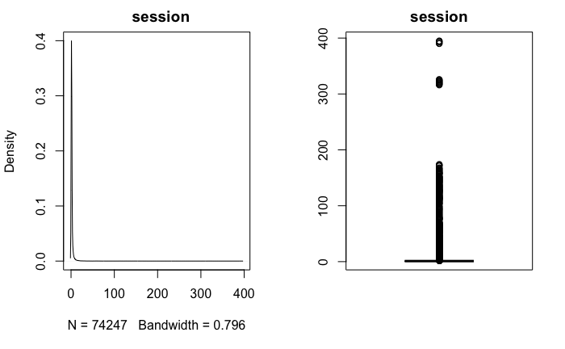

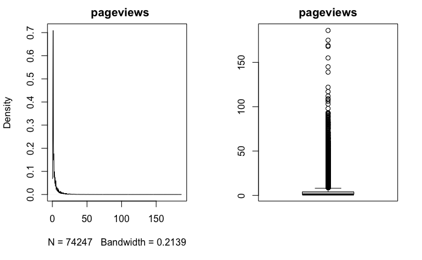

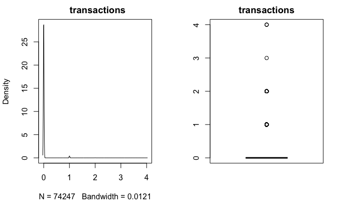

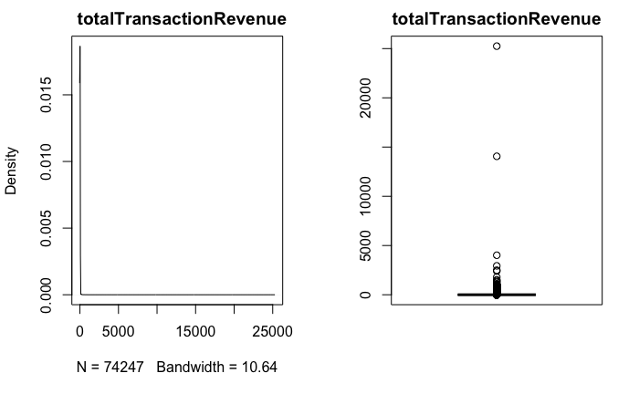

```r
par(mfrow=c(1,2))

cols = colnames(df2)
for (i in cols) {
     fieldName =  names(df2[i])
     title = paste(" ", fieldName)
     plot(density(df2[[i]]), main=title)  # densitiy plot
     #hist(df2[[i]], main=title, ylab="Frequency", xlab='')
     boxplot(df2[[i]], main =  fieldName) # box plot
  }
```

#### - Values are nominal, essentially 0 or close to it.

#### - Most are right skewed and transactions have multiple peaks.

## Univariate plots

#### Which browsers contribute to transactions?

```r
grouped_data = df %>%
  group_by(browser) %>%
  filter(hasTransaction == 'yes')  %>%
  distinct(userID, sessionID, transactions, browser)  %>%
  mutate( total_transactions_per_user = sum(transactions))  %>%
  summarise(browser, total_transactions_per_user)  %>%
  arrange(-total_transactions_per_user)

# remove duplicates
grouped_data = grouped_data[!duplicated(grouped_data), ]
head(grouped_data, 10)
```

| browser | total_transactions_per_user |
| --- | --- |
| Chrome | 1025 |
| Safari | 68 |
| Firefox | 13 |
| Internet Explorer | 7 |
| Edge | 2 |
| Opera | 2 |

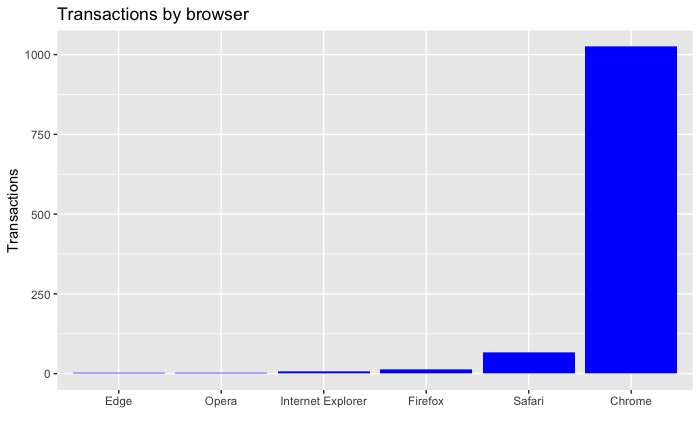

```r
ggplot(data = grouped_data,
  aes(x=reorder(browser, total_transactions_per_user), y = total_transactions_per_user)) +
  xlab('')  +
  ylab('Transactions')  +
  ggtitle('Transactions by browser')+
  theme(legend.position="none") +
  geom_bar(stat = "identity", fill='blue')
```

#### Chrome browser overwhelming contributes to transactions, followed by Safari

#### How do device contribute to Revenue?

```r
# unique by userID and sessionID
.data = df %>%
    filter(totalTransactionRevenue > 0)  %>%
    distinct(userID, sessionID, .keep_all = TRUE)

.data %>%
  group_by(deviceCategory) %>%
  summarise(deviceCategory = deviceCategory,
            totalRevenue = sum(totalTransactionRevenue)) %>%
  distinct(deviceCategory, totalRevenue)
```

| deviceCategory | totalRevenue |
| --- | --- |
| desktop | 162167.61 |
| mobile | 6910.10 |
| tablet | 552.15 |

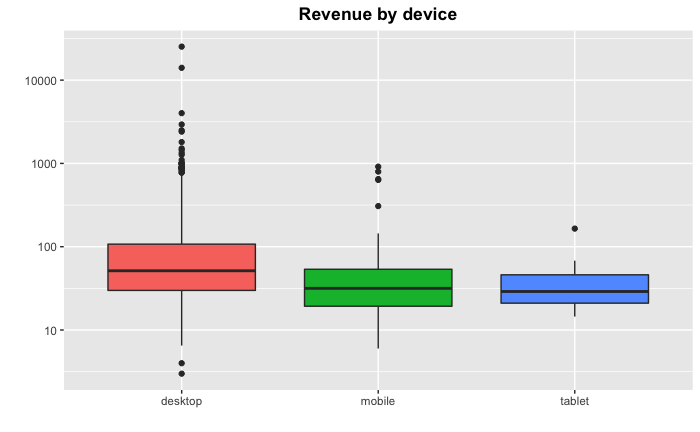

```r
qplot(data = .data, x=.data$deviceCategory, y=.data$totalTransactionRevenue,
      geom = "boxplot",
      xlab = '', ylab = '', main = 'Revenue by device',
      fill= .data$deviceCategory) +
      scale_y_continuous(trans='log10')  +   # log-scale for easier viewing
      theme(legend.position = "none",  # no legend
      plot.title = element_text(hjust = 0.5, face="bold")) # center
```

#### Here, we see desktop contribute the most to revenue followed by Mobile.

## Which countries contribute to transactions?

```r
grouped_data = df %>%
  group_by(country) %>%
  filter(hasTransaction == 'yes')  %>%
  distinct(userID, sessionID, transactions, country)  %>%
  mutate( total_transactions_per_user = sum(transactions))  %>%
  summarise(country, total_transactions_per_user)  %>%
  arrange(-total_transactions_per_user)

# remove duplicates
grouped_data = grouped_data[!duplicated(grouped_data), ]
head(grouped_data, 10)
```

| country | total_transactions_per_user |
| --- | --- |
| United States | 1073 |
| Canada | 19 |
| Germany | 2 |
| Indonesia | 2 |
| Israel | 2 |
| Mexico | 2 |
| Nigeria | 2 |
| United Kingdom | 2 |
| Argentina | 1 |
| China | 1 |

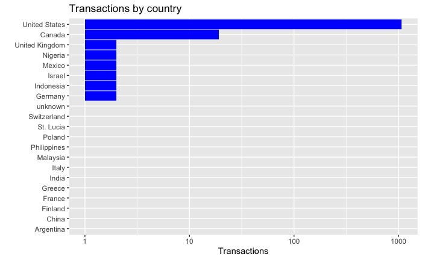

```r
ggplot(data = grouped_data, aes(x=reorder(country, total_transactions_per_user), y=total_transactions_per_user)) +
  coord_flip() +
  xlab('')  + ylab('Transactions')  +
  ggtitle('Transactions by country')+
  scale_y_continuous(trans='log10')  +   # log-scale for easier viewing
  theme(legend.position="none") +
  geom_bar(stat = "identity", fill='blue')
```

#### Most transactions originate from the US, followed by Canada. The transactions from other countries are nominal in comparison.

## How does region contribute to Revenue?

```r
grouped_data = df %>%
  group_by(region) %>%
  filter(hasTransaction == 'yes')  %>%
  distinct(userID, sessionID, totalTransactionRevenue, region)  %>%
  mutate( totalrev_per_region = sum(totalTransactionRevenue))  %>%
  summarise(region, totalrev_per_region)  %>%
  arrange(-totalrev_per_region)

# remove dups
grouped_data = grouped_data[!duplicated(grouped_data), ]
grouped_data
```

| region | totalrev_per_region |
| --- | --- |
| unknown | 80884.04 |
| California | 43869.50 |
| New York | 16017.95 |
| Texas | 4181.62 |
| Illinois | 4093.42 |
| Michigan | 3934.99 |
| Massachusetts | 3598.76 |
| Georgia | 3082.15 |
| Washington | 3030.39 |
| Virginia | 2494.00 |

[output cut: 22 more lines]

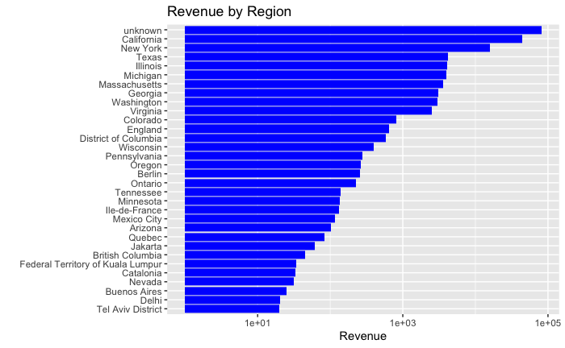

```r
ggplot(data = grouped_data, aes( x=reorder(region, totalrev_per_region),
  y = totalrev_per_region)) +
  coord_flip() +
  xlab('')  + ylab('Revenue')  +
  ggtitle('Revenue by Region')+
  scale_y_continuous(trans='log10')  +   # log-scale for easier viewing
  theme(legend.position="none") +
  geom_bar(stat = "identity", fill='blue')
```

## What’s the relationship between page views and conversion rate?

```r
#page-views vs conversion_rate
grouped_data = data %>%
  group_by(pageviews) %>%
  summarise(conversion_rate=mean(converted))

head(grouped_data, 10)
```

| pageviews | conversion_rate |
| --- | --- |
| 1 | 0.0000000000 |
| 2 | 0.0000000000 |
| 3 | 0.0003118179 |
| 4 | 0.0007460831 |
| 5 | 0.0003429355 |
| 6 | 0.0004780115 |
| 7 | 0.0023909145 |
| 8 | 0.0055335968 |
| 9 | 0.0038350911 |
| 10 | 0.0210135970 |

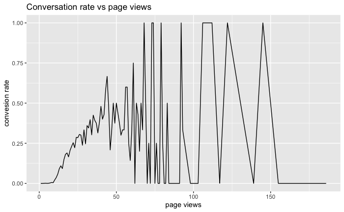

```r
qplot(x=pageviews, y=conversion_rate,
      data=grouped_data, geom="line",
      main = 'Conversation rate vs page views',
      xlab = 'page views',
      ylab = 'convesion rate')
```

#### Conversation rate increases linearly with higher page views up to around 50 at which point the trend is a bit random.

## How are transactions distributed across days of the week?

```r
grouped_data = df %>%
  group_by(userID) %>%
  filter(hasTransaction == 'yes')  %>%
  distinct(date, userID, sessionID, transactions, dow)  %>%
  mutate( total_transactions_per_user = sum(transactions) ) %>%
  arrange(-total_transactions_per_user)


grouped_data$dow <- as.factor(grouped_data$dow )
head(grouped_data, 10)
```

| date | userID | sessionID | transactions | dow | total_transactions_per_user |
| --- | --- | --- | --- | --- | --- |
| 2017-07-13 | 9417857471295131648 | 1499951313 | 2 | 5 | 9 |
| 2017-07-17 | 9417857471295131648 | 1500332130 | 1 | 2 | 9 |
| 2017-07-18 | 9417857471295131648 | 1500404409 | 2 | 3 | 9 |
| 2017-07-21 | 9417857471295131648 | 1500657634 | 2 | 6 | 9 |
| 2017-07-28 | 9417857471295131648 | 1501255344 | 2 | 6 | 9 |
| 2017-07-19 | 4260968995177655808 | 1500482145 | 1 | 4 | 5 |
| 2017-07-19 | 4260968995177655808 | 1500485087 | 1 | 4 | 5 |
| 2017-07-24 | 4260968995177655808 | 1500920072 | 3 | 2 | 5 |
| 2017-07-17 | 5584411114546174976 | 1500321920 | 4 | 2 | 5 |
| 2017-07-26 | 5584411114546174976 | 1501097257 | 1 | 4 | 5 |

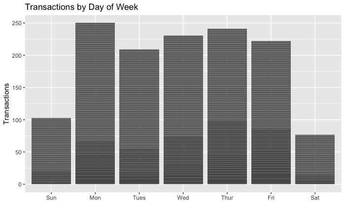

```r
grouped_data %>%
  ggplot( aes(x = dow, y = total_transactions_per_user)) +
    ylab('Transactions') + xlab('') +
    ggtitle("Transactions by Day of Week") +
    #geom_boxplot() +
    geom_bar(stat = "identity", show.legend = FALSE) +
    scale_x_discrete(labels = c('Sun','Mon', 'Tues', 'Wed', 'Thur', 'Fri', 'Sat'))
```

#### Most transactions occur on Monday and decrease through-out the week with an upward trend on Wed and Thurs before dropping. The weekends show the least amount of transactions

#### Session activity by date

```r
cum_sesson_totals = df %>%
  group_by(date) %>%
  filter(hasTransaction == 'yes')  %>%
  distinct(date, userID, sessionID, session)  %>%
  summarize(total_sessions = sum(session))

head(cum_sesson_totals, 10)
```

| date | total_sessions |
| --- | --- |
| 2017-07-01 | 19 |
| 2017-07-02 | 167 |
| 2017-07-03 | 34 |
| 2017-07-04 | 15 |
| 2017-07-05 | 120 |
| 2017-07-06 | 80 |
| 2017-07-07 | 153 |
| 2017-07-08 | 29 |
| 2017-07-09 | 47 |
| 2017-07-10 | 111 |

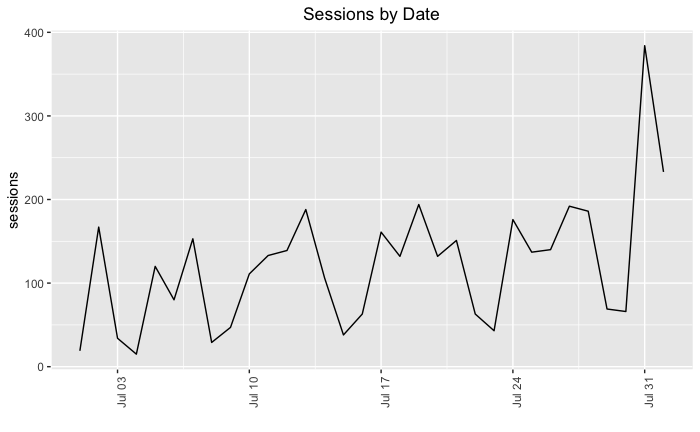

```r
ggplot(cum_sesson_totals, aes(x=date, y=total_sessions )) +
  geom_line() +
  xlab('') + ylab('sessions') + ggtitle("Sessions by Date") +
  theme(plot.title = element_text(hjust = 0.5)) + # center title
  theme(axis.text.x = element_text(angle = 90, hjust = 1))  #rotate x-axis
```

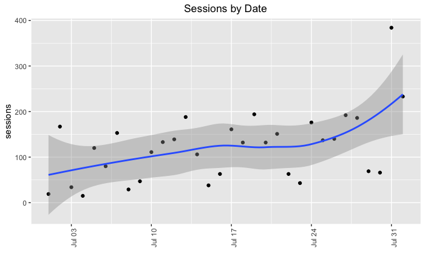

```r
ggplot(cum_sesson_totals, aes(x = date, y = total_sessions) ) +
  xlab('') + ylab('sessions') + ggtitle("Sessions by Date") +
  geom_point() +
  geom_smooth() +
  theme(plot.title = element_text(hjust = 0.5)) + # center title
  theme(axis.text.x = element_text(angle = 90, hjust = 1))
```

#### Session activity is cyclical through-out the month, corresponding to drops during the weekend, but the overall trend is upward.

## Analysis Questions

### Note: you may need to create aggregated fields as well as filter to be able to answer the following questions

#### 1) What was the average number of product pageviews for users who made a purchase?

#### SUM(total_pagesviews_per_user) / COUNT(users)

#### Answer: 27.999

```r
df2 = df %>%
  group_by(userID) %>%
  filter(hasTransaction == 'yes' )  %>%
  distinct(userID, sessionID, pageviews)

head(df2, 10)
```

| userID | sessionID | pageviews |
| --- | --- | --- |
| 6911334202687206 | 1500442011 | 19 |
| 10295111715775250 | 1501549997 | 35 |
| 14262055593378384 | 1499123682 | 30 |
| 14262055593378384 | 1500139462 | 26 |
| 24932550342595468 | 1500744389 | 26 |
| 47078955120420928 | 1501541991 | 21 |
| 80479763428955072 | 1500646191 | 34 |
| 82806901961150592 | 1501008172 | 51 |
| 88657980877164096 | 1499463211 | 14 |
| 97371986665596416 | 1501245017 | 14 |

```r
# count of unique rows by userID
total_unique_users = df2 %>%
   distinct(userID)  %>%
   nrow()

print('AVG number of product page views for users who made a purchase')
```

```
[1] "AVG number of product page views for users who made a purchase"
```

```r
sum(df2$pageviews)/total_unique_users
```

```
[1] 27.999
```

## 2) What was the average number of product pageviews for users who did not make a purchase?

### Answer:

### 4.21

```r
df2 = df %>%
  group_by(userID) %>%
  filter(hasTransaction == 'no' )  %>%
  distinct(userID, sessionID, pageviews)

head(df2, 10)
```

| userID | sessionID | pageviews |
| --- | --- | --- |
| 62267706107999 | 1499645960 | 1 |
| 85059828173212 | 1500505105 | 1 |
| 436683523507380 | 1500504900 | 2 |
| 436683523507380 | 1500989127 | 8 |
| 450371054833295 | 1500303787 | 1 |
| 572434142265465 | 1500605115 | 3 |
| 884932399915132 | 1499010813 | 8 |
| 1285462512259769 | 1499086856 | 1 |
| 1285462512259769 | 1499164789 | 1 |
| 1399220722808057 | 1500076255 | 5 |

```r
# count of unique rows by userID
total_unique_users = df2 %>%
   distinct(userID)  %>%
   nrow()

print('AVG number of product page views for users who made a purchase')
```

```
[1] "AVG number of product page views for users who made a purchase"
```

```r
sum(df2$pageviews)/total_unique_users
```

```
[1] 4.215753
```

## 3) What was the average total transactions per user that made a purchase?

### SUM (total_transactions_per_user) / COUNT(userID)

### Answer: 1.117

```r
df2 = df %>%
  group_by(userID) %>%
  filter(hasTransaction == 'yes')  %>%
  distinct(userID, sessionID, transactions)  %>%
  mutate( total_transactions_per_user = sum(transactions))
  #head(10)

head(df2, 10)
```

| userID | sessionID | transactions | total_transactions_per_user |
| --- | --- | --- | --- |
| 6911334202687206 | 1500442011 | 1 | 1 |
| 10295111715775250 | 1501549997 | 1 | 1 |
| 14262055593378384 | 1499123682 | 2 | 3 |
| 14262055593378384 | 1500139462 | 1 | 3 |
| 24932550342595468 | 1500744389 | 2 | 2 |
| 47078955120420928 | 1501541991 | 1 | 1 |
| 80479763428955072 | 1500646191 | 1 | 1 |
| 82806901961150592 | 1501008172 | 1 | 1 |
| 88657980877164096 | 1499463211 | 1 | 1 |
| 97371986665596416 | 1501245017 | 1 | 1 |

```r
# sum unique transactions by user ID
unique_transactions = df2 %>%
   distinct(total_transactions_per_user)
total_unique_transactions = sum(unique_transactions$total_transactions_per_user)

# count of unique rows by userID
total_unique_users = df2 %>%
   distinct(userID)  %>%
   nrow()


print('AVG total transactions per user that made a purchase')
```

```
[1] "AVG total transactions per user that made a purchase"
```

```r
total_unique_transactions / total_unique_users
```

```
[1] 1.117
```

## 4) What is the average amount of money spent per session?

#### SUM(total_transactionrevenue_per_user) / SUM(total_visits_per_user)

#### Answer: 157.9421 (eg: 157942141/1000000)

```r
df2 = df %>%
  group_by(userID,  visits, totalTransactionRevenue) %>%
  filter(hasTransaction == 'yes' & totalTransactionRevenue > 0)  %>%
  distinct(userID, totalTransactionRevenue, pageviews)
  #summarise(userID, totalTransactionRevenue, pageviews)

head(df2, 10)
```

| userID | pageviews | visits | totalTransactionRevenue |
| --- | --- | --- | --- |
| 6911334202687206 | 19 | 1 | 66.50 |
| 10295111715775250 | 35 | 1 | 8.39 |
| 14262055593378384 | 30 | 1 | 50.21 |
| 14262055593378384 | 26 | 1 | 24.58 |
| 24932550342595468 | 26 | 1 | 159.68 |
| 47078955120420928 | 21 | 1 | 48.16 |
| 80479763428955072 | 34 | 1 | 150.96 |
| 82806901961150592 | 51 | 1 | 173.27 |
| 88657980877164096 | 14 | 1 | 74.19 |
| 97371986665596416 | 14 | 1 | 49.20 |

```r
print('AVG  amount of money spent per session')
```

```
[1] "AVG  amount of money spent per session"
```

```r
sum(df2$totalTransactionRevenue)/ sum(df2$visits)
```

```
[1] 157.9421
```

#### 5) What is the total number of transactions generated per browser type?

```r
df2=df %>%
  group_by(browser) %>%
  #filter(hasTransaction == 'yes')  %>%
  distinct(userID, sessionID, transactions, browser)  %>%
  mutate( total_transactions_per_user = sum(transactions))  %>%
  summarise(browser, total_transactions_per_user)  %>%
  arrange(-total_transactions_per_user)

df2 = df2[!duplicated(df2), ]
df2
```

| browser | total_transactions_per_user |
| --- | --- |
| Chrome | 1025 |
| Safari | 68 |
| Firefox | 13 |
| Internet Explorer | 7 |
| Edge | 2 |
| Opera | 2 |
| (not set) | 0 |
| [Use default User-agent string] LIVRENPOCHE | 0 |
| 0 | 0 |
| Amazon Silk | 0 |

[output cut: 20 more lines]

## Regression Models

#### Normal Distribution assumption

#### For linear and logistic regression, we ideally want to make sure that the relationship between input and output variables are approximately linear.

```r
df2 = df %>%
  group_by(session) %>%
  filter( totalTransactionRevenue > 0)   %>%
  distinct(userID, sessionID, pageviews, transactions, totalTransactionRevenue,
           dow, deviceCategory, region)

df2 %>%
  select(-c(userID, sessionID, dow, deviceCategory, region))  %>%
  summary()
```

```
    session          pageviews       transactions  totalTransactionRevenue
 Min.   :  1.000   Min.   :  3.00   Min.   :1.00   Min.   :    2.99
 1st Qu.:  1.000   1st Qu.: 16.00   1st Qu.:1.00   1st Qu.:   28.36
 Median :  2.000   Median : 22.00   Median :1.00   Median :   49.21
 Mean   :  3.632   Mean   : 26.07   Mean   :1.04   Mean   :  157.94
 3rd Qu.:  4.000   3rd Qu.: 32.00   3rd Qu.:1.00   3rd Qu.:  103.37
 Max.   :111.000   Max.   :145.00   Max.   :4.00   Max.   :25249.26
```

#### Statistics reveals median revenue of 49 while mean is 158, again an indication of positive skew. This is not too surprising in that monetary values (eg: incomes, customer value, purchase sizes) are common sources of skewed distributions.

#### Monetary amounts are often lognormally distributed (Eg: the log of the data is normally distributed). Hence by taking the log of we can restore symmetry to it, as shown below.

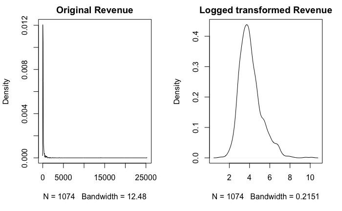

```r
par(mfrow=c(1,2))

plot(density(df2$totalTransactionRevenue), main='Original Revenue')

plot(density(log(df2$totalTransactionRevenue)), main='Logged transformed Revenue')
```

## Correlation

```r
library(corrplot)
data = df2 %>%
  mutate(revenue = log(totalTransactionRevenue))  %>%
  select(-c(userID, sessionID, totalTransactionRevenue))

M <- cor(data[,c('session', 'pageviews', 'transactions', 'revenue')])
print(M)
```

```
                session  pageviews transactions   revenue
session      1.00000000 0.03153162   0.08277062 0.1760106
pageviews    0.03153162 1.00000000   0.20860723 0.2569354
transactions 0.08277062 0.20860723   1.00000000 0.1988369
revenue      0.17601060 0.25693539   0.19883695 1.0000000
```

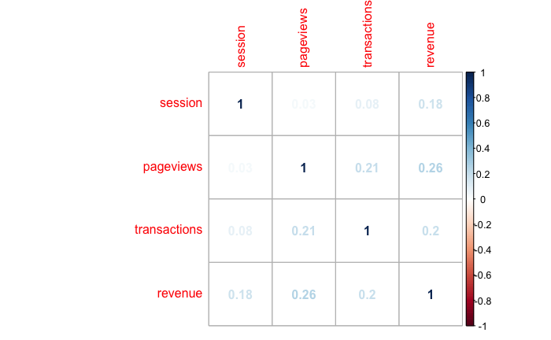

```r
corrplot(M, method="number")
```

### None of the input variables are strongly correlated to revenue, though page views (0.26) has the strongest correlation

## Multiple Linear regression model (Revenue Predicting)

```r
model1<-lm(revenue ~ ., data)
summary (model1)
```

```
Call:
lm(formula = revenue ~ ., data = data)

Residuals:
    Min      1Q  Median      3Q     Max
-3.0244 -0.6645 -0.1378  0.5058  5.3659

Coefficients:
                                         Estimate Std. Error t value Pr(>|t|)
(Intercept)                              2.872256   0.733704   3.915 9.64e-05 ***
session                                  0.021162   0.005747   3.682 0.000243 ***
pageviews                                0.016447   0.002157   7.625 5.52e-14 ***
transactions                             0.602029   0.133782   4.500 7.56e-06 ***
deviceCategorymobile                    -0.419363   0.114555  -3.661 0.000264 ***
deviceCategorytablet                    -0.443559   0.285446  -1.554 0.120510
regionBerlin                             1.567602   1.243317   1.261 0.207657
regionBritish Columbia                   0.080110   1.245667   0.064 0.948735
regionBuenos Aires                      -0.770093   1.243324  -0.619 0.535801
regionCalifornia                         0.062631   0.721137   0.087 0.930807
regionCatalonia                         -0.081190   1.242634  -0.065 0.947918
regionColorado                           0.310458   0.787085   0.394 0.693337
regionDelhi                             -0.896596   1.243020  -0.721 0.470885
regionDistrict of Columbia               0.049021   0.803054   0.061 0.951337
regionEngland                            1.026347   1.015466   1.011 0.312389
regionFederal Territory of Kuala Lumpur  0.125949   1.243223   0.101 0.919325
regionGeorgia                            0.652721   0.763291   0.855 0.392671
regionIle-de-France                      1.007033   1.242772   0.810 0.417947
regionIllinois                           0.405072   0.742028   0.546 0.585253
regionJakarta                            0.311647   1.242955   0.251 0.802072
regionMassachusetts                      0.213454   0.751346   0.284 0.776393
regionMexico City                        0.618314   1.243434   0.497 0.619109
regionMichigan                           0.510797   0.753318   0.678 0.497883
regionMinnesota                         -0.008322   1.015427  -0.008 0.993462
regionNevada                            -0.976056   1.013640  -0.963 0.335812
regionNew York                           0.417273   0.725896   0.575 0.565525
regionOntario                            0.104999   0.878888   0.119 0.904928
regionOregon                            -0.170341   0.830382  -0.205 0.837506
regionPennsylvania                       0.126026   0.849957   0.148 0.882156
regionQuebec                             0.635102   1.243132   0.511 0.609538
regionTel Aviv District                 -0.707423   1.244046  -0.569 0.569719
regionTennessee                          0.326785   1.017788   0.321 0.748219
regionTexas                              0.258990   0.736435   0.352 0.725150
regionunknown                            0.045459   0.720389   0.063 0.949696
regionVirginia                           1.925497   1.374895   1.400 0.161673
regionWashington                        -0.021354   0.739068  -0.029 0.976955
regionWisconsin                          1.797626   1.243489   1.446 0.148583
dow                                     -0.004609   0.018011  -0.256 0.798055
---
Signif. codes:  0 ‘***’ 0.001 ‘**’ 0.01 ‘*’ 0.05 ‘.’ 0.1 ‘ ’ 1

Residual standard error: 1.013 on 1036 degrees of freedom
Multiple R-squared:  0.162, Adjusted R-squared:  0.1321
F-statistic: 5.414 on 37 and 1036 DF,  p-value: < 2.2e-16
```

#### We can see that region and dow are not significant so lets create another model without these

```r
data = data %>%
  select(-c(region,dow))

names(data)
```

```
[1] "session"        "pageviews"      "transactions"   "deviceCategory" "revenue"
```

```r
model2<-lm(revenue ~ ., data)
summary (model2)
```

```
Call:
lm(formula = revenue ~ ., data = data)

Residuals:
    Min      1Q  Median      3Q     Max
-3.6201 -0.6775 -0.1474  0.5080  5.2371

Coefficients:
                      Estimate Std. Error t value Pr(>|t|)
(Intercept)           2.965028   0.142185  20.853  < 2e-16 ***
session               0.025922   0.004989   5.196 2.44e-07 ***
pageviews             0.016131   0.002135   7.557 8.86e-14 ***
transactions          0.621537   0.133272   4.664 3.50e-06 ***
deviceCategorymobile -0.480356   0.110086  -4.363 1.40e-05 ***
deviceCategorytablet -0.471167   0.284298  -1.657   0.0978 .
---
Signif. codes:  0 ‘***’ 0.001 ‘**’ 0.01 ‘*’ 0.05 ‘.’ 0.1 ‘ ’ 1

Residual standard error: 1.017 on 1068 degrees of freedom
Multiple R-squared:   0.13, Adjusted R-squared:  0.126
F-statistic: 31.92 on 5 and 1068 DF,  p-value: < 2.2e-16
```

#### Equation:

#### - Revenue = 2.965028 + 0.026(Session) + 0.016(Pageviews) + 0.621(Transactions) -0.480(Mobile) - 0.471(tablet)

#### The intercept (Desktop) base-line is 2.97 which is the average Revenue for Desktop devices. But the the average revenue for Mobile is -0.480 units lower while Tablet is -0.471 units lower. For each 1 unit increase in sessions the predicted increase in Revenue is 0.026. For each 1 unit increase in pageviews, the predicted increase in Revenue is 0.0161. For each 1 unit increase in transactions, the predicted increase in Revenue is 0.621.

## Model Comparison

```r
#anova(model2, model1, test="LRT") # Likelihood ratio tests
anova(model2, model1)
```

```
Analysis of Variance Table

Model 1: revenue ~ session + pageviews + transactions + deviceCategory
Model 2: revenue ~ session + pageviews + transactions + deviceCategory +
    region + dow
  Res.Df    RSS Df Sum of Sq      F Pr(>F)
1   1068 1104.6
2   1036 1064.0 32     40.64 1.2366 0.1728
```

#### The p-value for the model that includes Region is not significant. This means the 2 models are not significantly different in terms of model performance. Hence adding the Region does not improve the model.

## Evaluating Model Assumptions

```
not plotting observations with leverage one:
  145, 489, 517, 682, 719, 744, 796, 884, 980, 1039, 1068
```

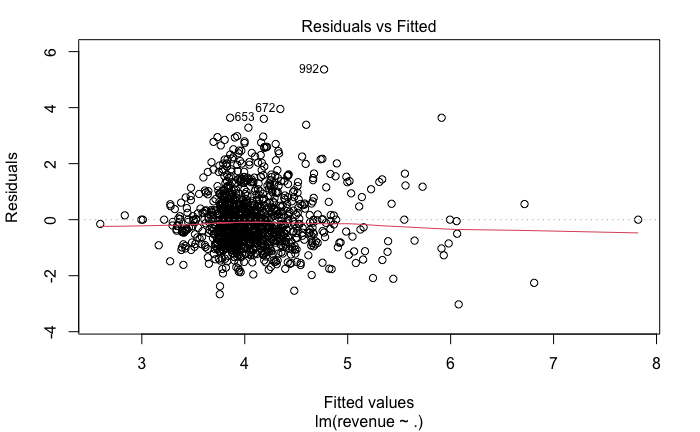

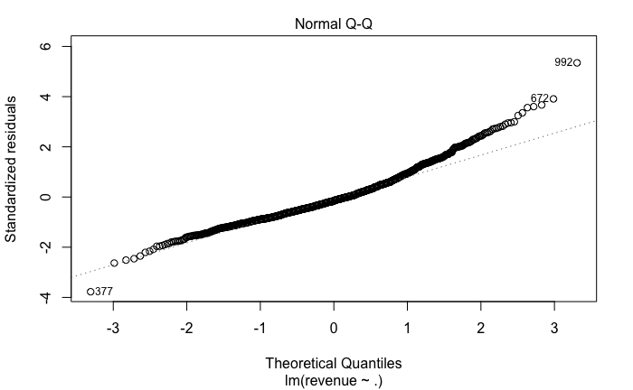

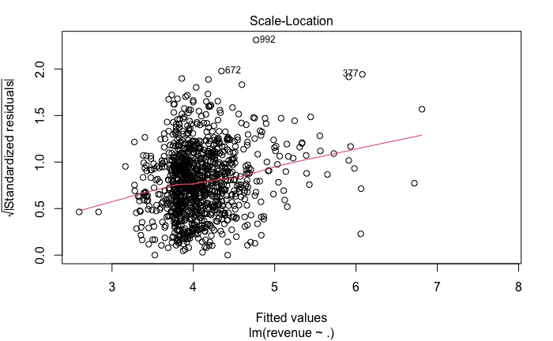

```
NaNs producedNaNs produced
```

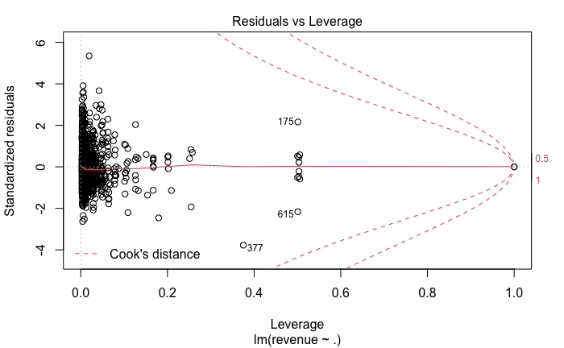

```r
plot(model1)
```

#### - Residuals vs. Leverage plots: helps identify influential data points in the model by looking for cases outside of a dashed line (eg:Cook’s distance). We’re looking for values in the upper right or lower right corners, which are outside Cook’s distance line. Such points would be influential in the model and removing them would likely noticeably alter the regression results. In this case, there are no outliers ouside of cook’s distance.